# Prosper Loan Data Explanatory analysis

## by Sodiq Babatunde

## Introduction

This project is on a data set from Prosper, which is America’s first marketplace lending platform, with over $7 billion in funded loans. This data set contains 113,937 loans with 81 variables on each loan, including loan amount, borrower rate (or interest rate), current loan status, borrower income, borrower employment status, borrower credit history, and the latest payment information. The main purpose of this project is to summarize the characteristics of variables that can affect the loan status and to get some ideas about the relationships among multiple variables using summary statistics and data visualizations.

### Investigation overview

The main purpose of this project is to summarize the characteristics of variables that can affect the loan status and to get some ideas about the relationships among multiple variables using summary statistics and data visualizations.

## Relationship between borrowerrate and estimated effective yield

It can be deduced from the visualization that there is a strong postive relatiinship between the two variable i.e the higher the interest rate the happier the Lender.

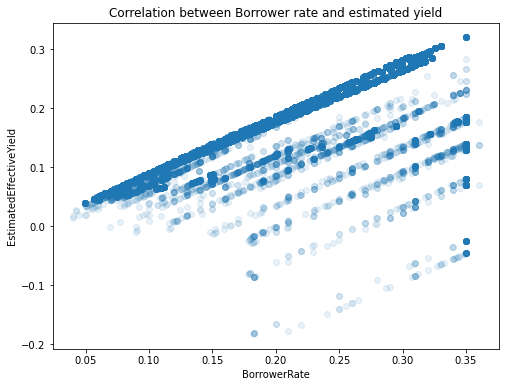

```python
plt.figure(figsize = [8, 6])
plt.scatter(data = Loan, y = 'EstimatedEffectiveYield', x = 'BorrowerRate', alpha = 1/10)
plt.ylabel('EstimatedEffectiveYield')
plt.xlabel('BorrowerRate')
plt.title('Correlation between Borrower rate and estimated yield')
plt.show()
```

## Checking the highest loan status

It can be seen that most people are currently taking loan followed by those that just completed their loan. It's quite impressive that number of defaulters are not too much.

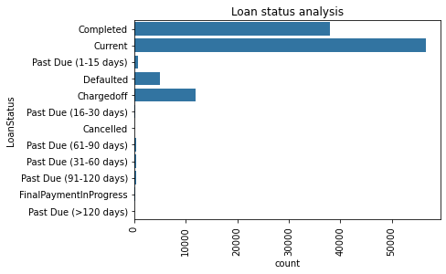

```python
default_color = sb.color_palette()[0]
sb.countplot(data = Loan, y = 'LoanStatus',color=default_color )
plt.title('Loan status analysis')
plt.xticks(rotation=90);
```

## BorrowerRate pattern over years

Point plot is used to analyze this and it suites the analysis because this graph shows the nature of the variable from one xfactor to another. For this scenario, it shows that rate of interest increased from 2005-2006 and then fell off from 2006-2007 and then it constantly picked up for few years, reached its peak in 2011 which then started decreasing constantly.

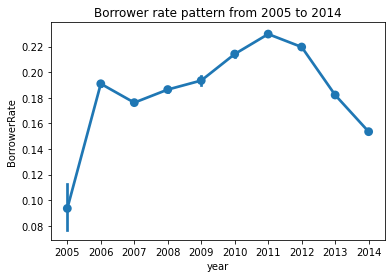

```python
Loan['year'] = Loan.ListingCreationDate.str.split('-').str[0]

# plots the pointplot for year vs BorrowerRate
order_date = ['2005','2006','2007','2008','2009','2010','2011','2012','2013','2014']

sb.pointplot(data=Loan, x='year', y='BorrowerRate', order=order_date)
plt.title('Borrower rate pattern from 2005 to 2014');
```